# Recidivism Prediction in Broward County, FL

Xingxing Shu

## 1. Introduction

Preventing recidivism, the repeat incarceration of a previously released offender, is an opportunity to break the cycle of incarceration that affects hundreds of thousands of people in the US.Recidivism, or the repeat incarceration of an ex-offender, is a preventable problem. When an ex-offender re-offends, the community and the individual both suffer social and financial loss.In mid-2016, [ProPublica](https://www.propublica.org/article/machine-bias-risk-assessments-in-criminal-sentencing) published an analysis of a machine learning tool built by a company called Northpointe to assess the “rehabilitation needs” of Broward County, Florida inmates.A traditional solution, to expressly exclude race from the model, is insufficient because other variables, such as education, residence, and certain crime types, are strongly correlated with race and serve as race indicators in the model. In this project, I tried to understand the extent of racial bias and demonstrate accuracy & generalizability metrics by exploring the trade-off in model predictions between maximizing social benefits and maximizing fairness.

## 2. Load data and exploratory analysis

```r
options(dplyr.width = Inf)

library(tidyverse)
library(ggalluvial)
library(ModelMetrics)
library(caret)
library(plotROC)
library(knitr)
library(kableExtra)
library(grid)
library(gridExtra)
library(reshape2)

plotTheme <- function(base_size = 12) {
  theme(
    text = element_text( color = "black"),
    plot.title = element_text(size = 14,colour = "black"),
    plot.subtitle = element_text(face="italic"),
    plot.caption = element_text(hjust=0),
    axis.ticks = element_blank(),
    panel.background = element_blank(),
    panel.grid.major = element_line("grey80", size = 0.1),
    panel.grid.minor = element_blank(),
    panel.border = element_rect(colour = "black", fill=NA, size=2),
    strip.background = element_rect(fill = "grey80", color = "white"),
    strip.text = element_text(size=12),
    axis.title = element_text(size=12),
    axis.text = element_text(size=10),
    plot.background = element_blank(),
    legend.background = element_blank(),
    legend.title = element_text(colour = "black", face = "italic"),
    legend.text = element_text(colour = "black", face = "italic"),
    strip.text.x = element_text(size = 14)
  )
}

palette_9_colors <- c("#C85B6C","#FE7568","#FCCA6C","#548FCC","#315B8A","#00A691","#44ABC2","#A6E6F4","#F5D2B3")
palette_8_colors <- c("#0DA3A0","#2D97AA","#4D8CB4","#6E81BF","#8E76C9","#AF6BD4","#CF60DE","#F055E9")
palette_7_colors <- c("#2D97AA","#4D8CB4","#6E81BF","#8E76C9","#AF6BD4","#CF60DE","#F055E9")
palette_6_colors <- c("#C85B6C","#FE7568","#FCCA6C","#548FCC","#315B8A","#00A691")
palette_5_colors <- c("#2D97AA","#6E81BF","#8E76C9","#AF6BD4","#F055E9")
palette_3_colors <- c("#C85B6C","#FCCA6C","#315B8A")
palette_2_colors <- c("#C85B6C","#315B8A")
palette_1_colors <- c("#0DA3A0")
```

```r
raw_data <- read.csv("https://raw.githubusercontent.com/propublica/compas-analysis/master/compas-scores-two-years.csv")

df <-
  raw_data %>%
  filter(days_b_screening_arrest <= 30) %>%
  filter(days_b_screening_arrest >= -30) %>%
  filter(is_recid != -1) %>%
  filter(c_charge_degree != "O") %>%
  filter(priors_count != "36") %>%
  filter(priors_count != "25") %>%
  mutate(length_of_stay = as.numeric(as.Date(c_jail_out) - as.Date(c_jail_in)),
         priors_count = as.factor(priors_count),
         Recidivated = as.factor(ifelse(two_year_recid == 1,"Recidivate","notRecidivate"))
         ) %>%
  select(sex,age,age_cat,race,priors_count,two_year_recid,r_charge_desc,
         c_charge_desc,c_charge_degree,r_charge_degree,juv_other_count,
         length_of_stay,priors_count,Recidivated,is_violent_recid)
```

The original dataset contains 7,214 inmates with 53 variables, after selection, the new data includes 6,163 inmates in Broward County. Of those, 2,801 are listed as having a recidivism event. 51% of the inmates are African American and 81% are males.

```r
library(knitr)
library(kableExtra)

text_tbl <- data.frame(
  Variables = c("sex", "age", "age_cat","race","priors_count", "two_year_recid","r_charge_desc","c_charge_desc","c_charge_degree","r_charge_degree","juv_other_count","length_of_stay","Recidivicated","is_violent_recid"),
  Explanation = c(
    "Sex of inmate (male/female)",
    "Age of inmate ", "Age of inmate as a categorical variable(Less than 25/25-45/Greater than 45)",
    "Race of inmate (Caucasian/African American/Asian/Hispanic/Native American/Other)",
    "The count of prior adult convictions",
    "Does the inmate recidivicate with 2 years after out of jail? (1/0)",
    "Description of the last crime of the inmate","Type of the crime",
    "Charge of the crime: Felony (F)/ Misdemeanor(M)",
    "Degree of the charge of the crime: (F1/F2/F3/F5/F6/F7/M1/M2/MO3/CO3)",
    "Times of crimes commited as juvenile","Days stayed in jail",
    "Whether the inmate recidivicated or not (Recidivate or notRecidivate)",
    "Whether the recidivicated crimes violent or not (1 or 0)"
  )
)

kable(text_tbl) %>%
  kable_styling(full_width = F) %>%
  column_spec(1, bold = T, border_right = T)%>%
  column_spec(2, width = "30em")
```

| Variables | Explanation |
| --- | --- |
| sex | Sex of inmate (male/female) |
| age | Age of inmate |
| age_cat | Age of inmate as a categorical variable(Less than 25/25-45/Greater than 45) |
| race | Race of inmate (Caucasian/African American/Asian/Hispanic/Native American/Other) |
| priors_count | The count of prior adult convictions |
| two_year_recid | Does the inmate recidivicate with 2 years after out of jail? (1/0) |
| r_charge_desc | Description of the last crime of the inmate |
| c_charge_desc | Type of the crime |
| c_charge_degree | Charge of the crime: Felony (F)/ Misdemeanor(M) |
| r_charge_degree | Degree of the charge of the crime: (F1/F2/F3/F5/F6/F7/M1/M2/MO3/CO3) |
| juv_other_count | Times of crimes commited as juvenile |
| length_of_stay | Days stayed in jail |
| Recidivicated | Whether the inmate recidivicated or not (Recidivate or notRecidivate) |
| is_violent_recid | Whether the recidivicated crimes violent or not (1 or 0) |

Below shows the visualization the frequency of initial charges for each inmate.

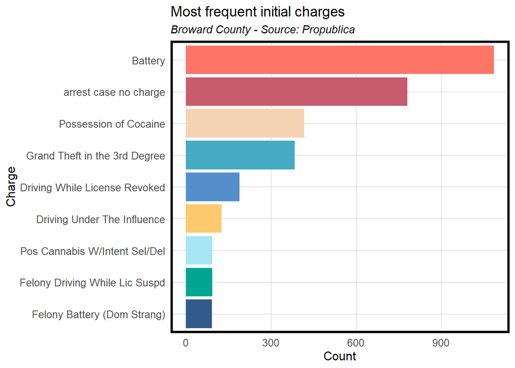

```r
df %>%
  group_by(c_charge_desc) %>%
  summarize(count = n()) %>%
  arrange(-count) %>%
  head(9) %>%
  ggplot(aes(reorder(c_charge_desc, count, FUN = max),
             count, fill = c_charge_desc)) +
  geom_col() +
  coord_flip() +
  scale_fill_manual(values=palette_9_colors) +
  theme(legend.position = "none") +
  labs(x = "Charge", y = "Count",
       title="Most frequent initial charges",
       subtitle= "Broward County - Source: Propublica") +
  plotTheme()
```

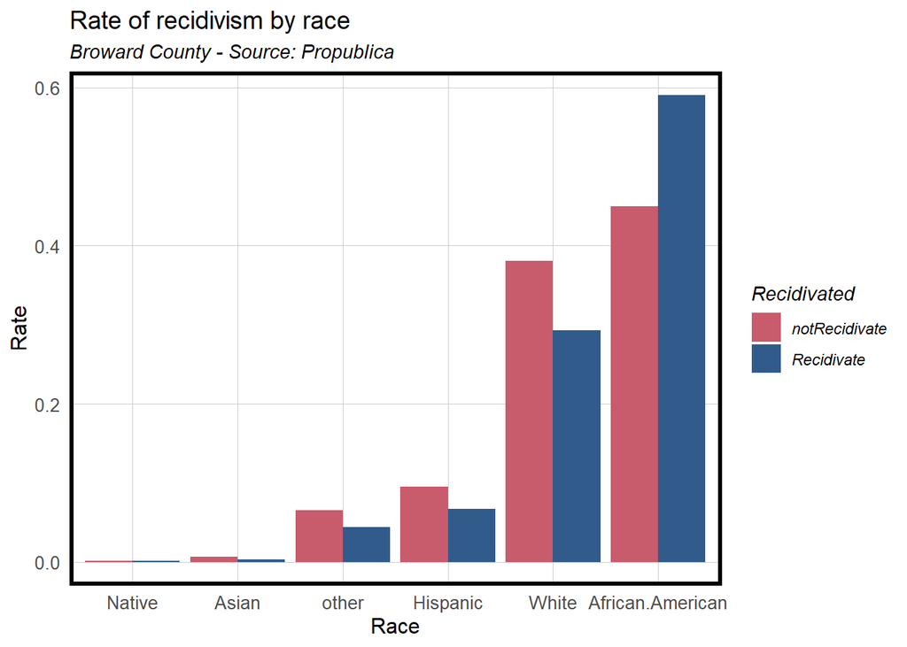

```r
df %>%
  group_by(Recidivated)%>%
  count(race)%>%
  summarize(sum_African = sum(n[race == 'African-American']),
            sum_Asian = sum(n[race == 'Asian']),
            sum_White = sum(n[race == 'Caucasian']),
            sum_Hispanic = sum(n[race == 'Hispanic']),
            sum_Native = sum(n[race == 'Native American']),
            sum_other = sum(n[race == 'Other']),
            total = sum(n)) %>%
  mutate(African.American = sum_African/total,
         Asian = sum_Asian/total,
         White = sum_White/total,
         Hispanic = sum_Hispanic/total,
         Native = sum_Native/total,
         other = sum_other/total) %>%
  select(Recidivated,African.American:other) %>%
  gather(key,value,African.American:other) %>%
  arrange(-value) %>%
    ggplot(.,aes(reorder(key,value, FUN = max),value,fill=Recidivated)) +
    geom_bar(aes(fill = Recidivated),position="dodge",stat="identity") +
    scale_fill_manual(values = palette_2_colors)  +
    labs(x = "Race", y = "Rate",
       title="Rate of recidivism by race",
       subtitle= "Broward County - Source: Propublica") +
    plotTheme()
```

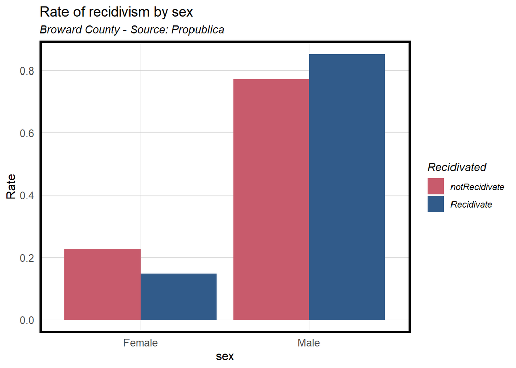

```r
df %>%
  group_by(Recidivated)%>%
  count(sex)%>%
  summarize(sum_male = sum(n[sex == 'Male']),
            sum_female = sum(n[sex == 'Female']),
            total = sum(n)) %>%
  mutate(Male = sum_male/total,
         Female = sum_female/total) %>%
  select(Recidivated,Male, Female) %>%
  gather(key,value,Male, Female) %>%
  arrange(-value) %>%
    ggplot(.,aes(reorder(key,value, FUN = max),value,fill=Recidivated)) +
    geom_bar(aes(fill = Recidivated),position="dodge",stat="identity") +
    scale_fill_manual(values = palette_2_colors)  +
    labs(x = "sex", y = "Rate",
       title="Rate of recidivism by sex",
       subtitle= "Broward County - Source: Propublica") +
    plotTheme()
```

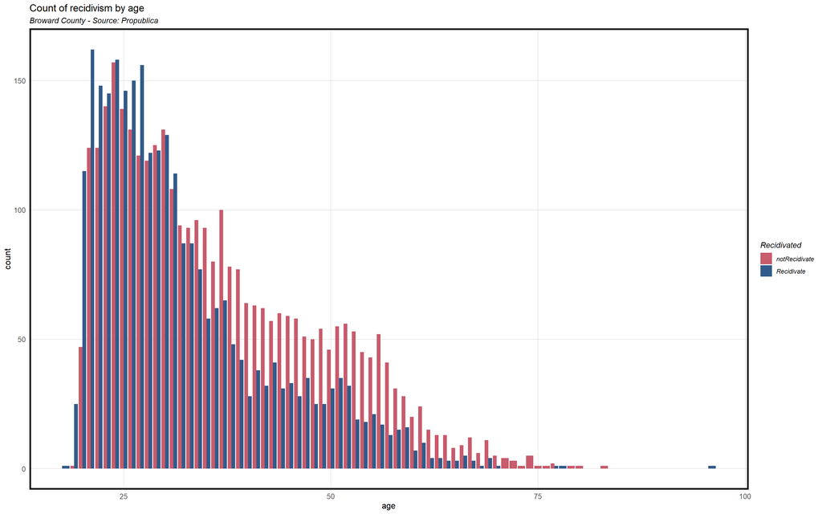

```r
df %>%
  group_by(Recidivated,age)%>%
  summarize(count = n()) %>%
    ggplot(., aes(x=age, y=count, fill=Recidivated)) +
    geom_bar(stat='identity', position='dodge')+
    scale_fill_manual(values = palette_2_colors)  +
    labs(x = "age", y = "count",
       title="Count of recidivism by age",
       subtitle= "Broward County - Source: Propublica") +
    plotTheme()
```

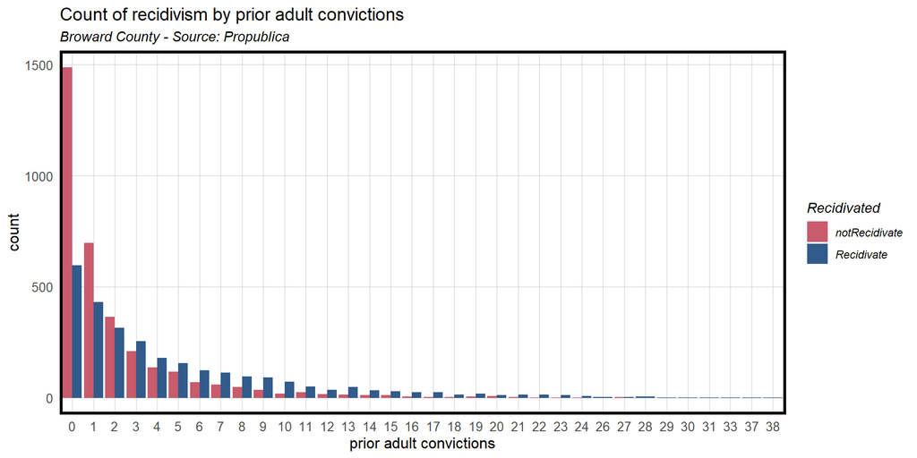

```r
df %>%
  group_by(Recidivated,priors_count)%>%
  summarize(count = n()) %>%
    ggplot(., aes(x=priors_count, y=count, fill=Recidivated)) +
    geom_bar(stat='identity', position='dodge')+
    scale_fill_manual(values = palette_2_colors)  +
    labs(x = "prior adult convictions", y = "count",
       title="Count of recidivism by prior adult convictions",
       subtitle= "Broward County - Source: Propublica") +
    plotTheme()
```

Finally, I visualize a Sankey diagram of how inmates recidivate. We could see that felony crimes decrease a lot in second recidivicated crimes instead of more misdemeanor crimes.

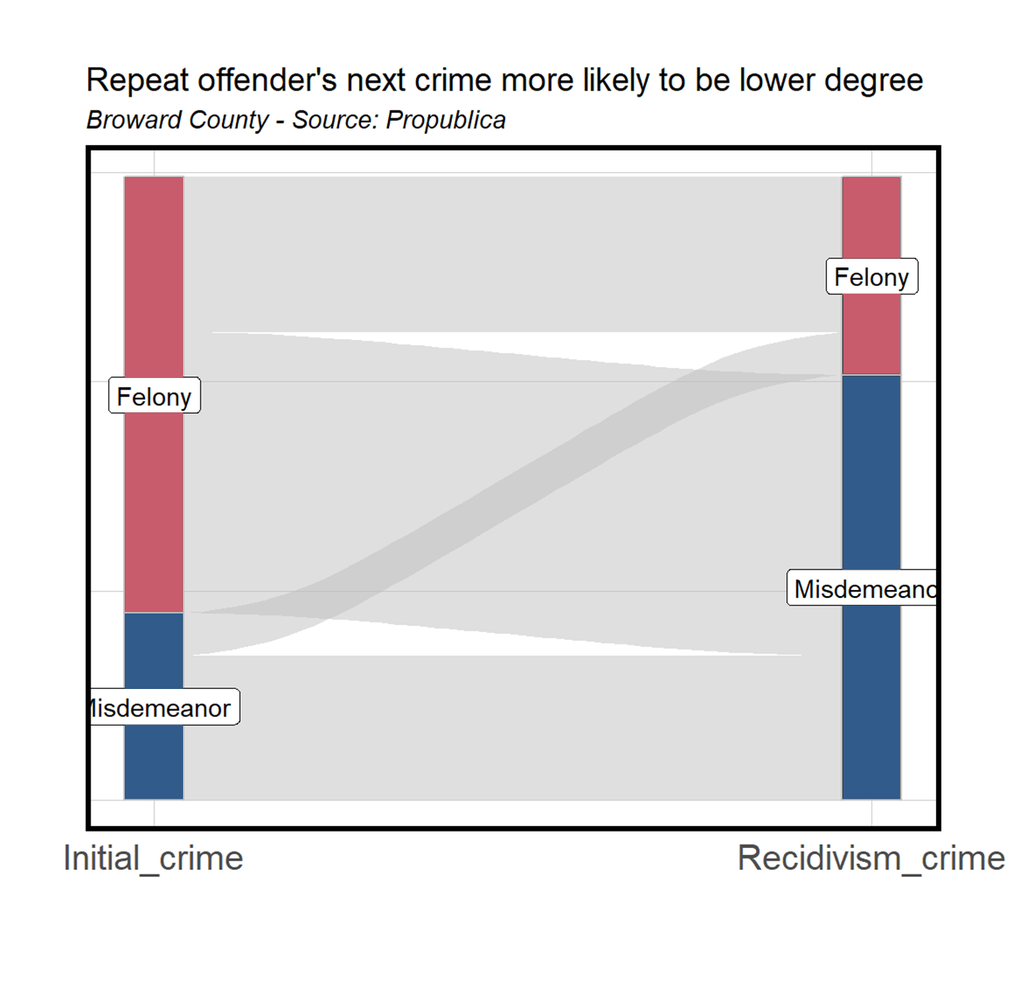

```r
library(magick)
sankey <- image_read('../sk.png')
image_scale(sankey)
```

## 3. Model Building

In this section I developed two predictive models, one with race and one without. You will do this in order to understand how the algorithm reacts to the inclusion of race as a control.

```r
set.seed(336)
trainIndex <- createDataPartition(df$priors_count, p = .75,
                                    list = FALSE,
                                    times = 1)
train <- df[ trainIndex,]
test  <- df[-trainIndex,]
```

```r
set.seed(125)
reg.noRace.cv <- train(Recidivated ~ ., data = train %>%
                                               select(-race,
                                               -r_charge_degree,
                                               -r_charge_desc,
                                               -c_charge_degree,
                                               -c_charge_desc,
                                               -two_year_recid),
 family="binomial"(link="logit"), method="glm",
 metric="ROC",
 trControl = trainControl(method = "cv",number = 40,classProbs = TRUE, summaryFunction=twoClassSummary))

reg.withRace.cv <- train(Recidivated ~ ., data = train %>%
                                               select(
                                               -r_charge_degree,
                                               -r_charge_desc,
                                               -c_charge_degree,
                                               -c_charge_desc,
                                               -two_year_recid),
 family="binomial"(link="logit"), method="glm",
 metric="ROC",
 trControl = trainControl(method = "cv",number = 40,classProbs = TRUE, summaryFunction=twoClassSummary))
```

```r
testProbs <-
  rbind(
    data.frame(class = test$two_year_recid,
               probs = predict(reg.noRace.cv, test, type="prob")$Recidivate,
               predClass = ifelse(predict(reg.noRace.cv, test, type="prob")$Recidivate > .5 ,1,0),
               regression = "No Race",
               Race = test$race),
    data.frame(class = test$two_year_recid,
               probs = predict(reg.withRace.cv, test, type="prob")$Recidivate,
               predClass = ifelse(predict(reg.withRace.cv, test, type="prob")$Recidivate > .5 ,1,0),
               regression = "With Race",
               Race=test$race))

head(testProbs)
##   class     probs predClass regression             Race
## 1     0 0.1267098         0    No Race            Other
## 2     1 0.5207060         1    No Race African-American
## 3     1 0.4754772         0    No Race         Hispanic
## 4     1 0.8763367         1    No Race African-American
## 5     1 0.7468538         1    No Race        Caucasian
## 6     1 0.5422434         1    No Race            Other
```

## 4. Evaluating accuracy

The overall AUC’s with and without race are both 0.77 which indicates the model without racial factor has nothing to do with the prediction. Therefore, race does not have a strong predictive power in an overall sense. To have a better view of the race factor, next we gonna check the accuracy by looking at the AUCs of the three major racial groups, Caucasians, African Americans, and Hispanics. Within each model, the AUCs show that the models predict the recidivism of African Americans the best, Hispanics the second, and Caucasians the third. Both models are almost equally accurate across racial groups.

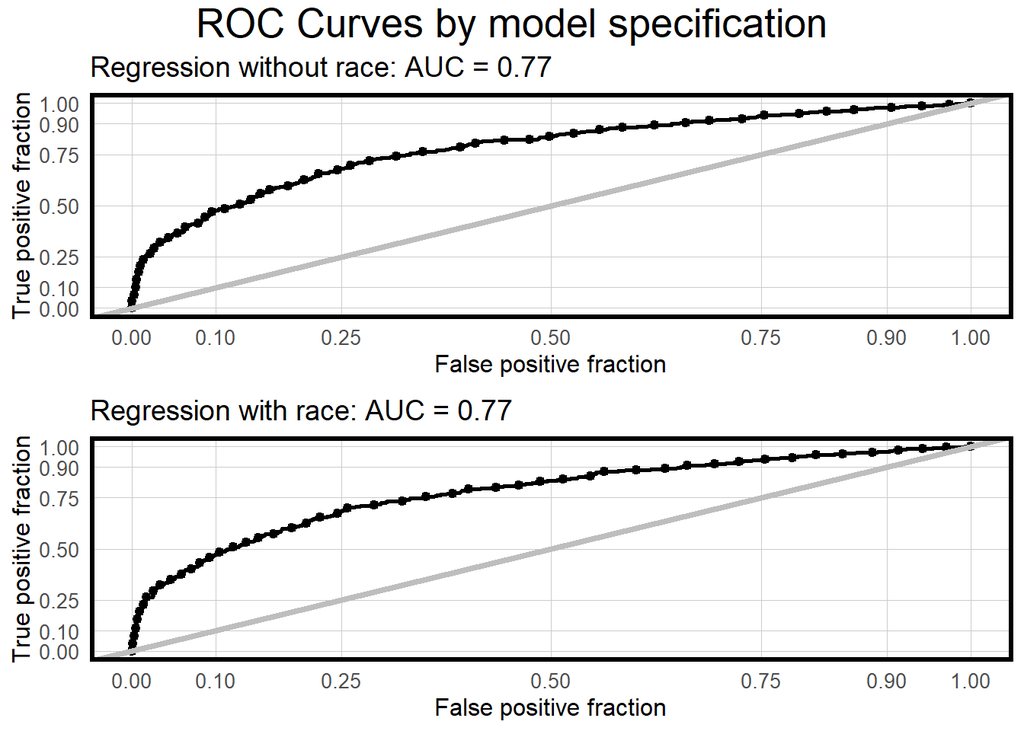

```r
roc.noRace <-
  ggplot(testProbs %>% filter(regression == "No Race"),
         aes(d = as.numeric(class), m = probs)) +
  geom_roc(n.cuts = 50, labels = FALSE) +
  style_roc(theme = theme_grey) +
  geom_abline(slope = 1, intercept = 0, size = 1.5, color = 'grey') +
  labs(title=paste("Regression without race: AUC =",
                    testProbs %>%
                     group_by(regression) %>%
                     summarize(AUC = auc(class,probs)) %>%
                     filter(regression == "No Race") %>%
                     pull(2) %>% as.character() %>% substr(.,1,4))) +
  plotTheme()

roc.withRace <-
  ggplot(testProbs %>% filter(regression == "With Race"),
         aes(d = as.numeric(class), m = probs)) +
  geom_roc(n.cuts = 50, labels = FALSE) +
  style_roc(theme = theme_grey) +
  geom_abline(slope = 1, intercept = 0, size = 1.5, color = 'grey') +
  labs(title=paste("Regression with race: AUC =",
                    testProbs %>%
                     group_by(regression) %>%
                     summarize(AUC = auc(class,probs)) %>%
                     filter(regression == "With Race") %>%
                     pull(2) %>% as.character() %>% substr(.,1,4))) +
  plotTheme()

grid.arrange(roc.noRace,roc.withRace,
  top=textGrob("ROC Curves by model specification", gp=gpar(fontsize=20)))
```

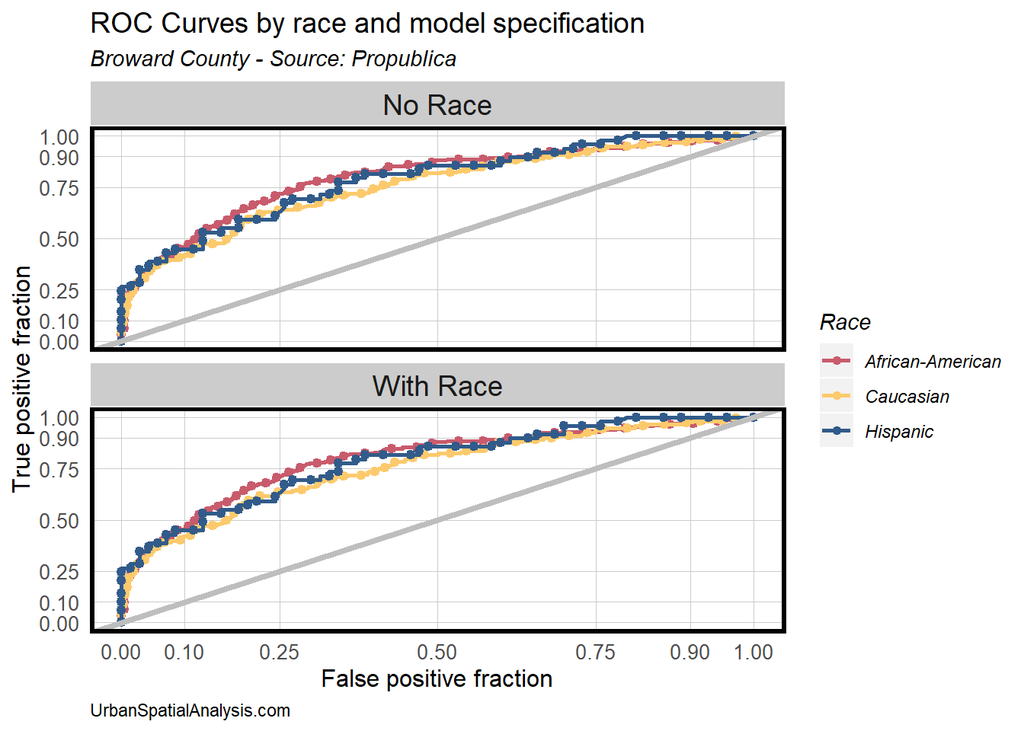

```r
ggplot(testProbs %>% filter(Race == "Caucasian" | Race == "African-American" | Race == "Hispanic"),
       aes(d = as.numeric(class), m = probs, group=Race, colour=Race)) +
  geom_roc(n.cuts = 50, labels = FALSE) +
  scale_color_manual(values = palette_3_colors) +
  style_roc(theme = theme_grey) +
  facet_wrap(~regression,ncol=1) +
  geom_abline(slope = 1, intercept = 0, size = 1.5, color = 'grey') +
  labs(title="ROC Curves by race and model specification",
       subtitle= "Broward County - Source: Propublica",
       caption="UrbanSpatialAnalysis.com") +
  plotTheme()
```

```r
testProbs %>%
  group_by(regression,Race) %>%
  summarize(AUC = auc(class,probs)) %>%
  filter(Race == "African-American" | Race == "Caucasian" | Race == "Hispanic") %>%
  arrange(Race) %>%
  kable() %>%
  kable_styling("striped", full_width = F) %>%
   row_spec(c(1:2), bold = F, color = "white", background = "#C85B6C") %>%
   row_spec(c(3:4), bold = F, color = "white", background = "#FCCA6C") %>%
   row_spec(c(5:6), bold = F, color = "white", background = "#315B8A")
```

| regression | Race | AUC |
| --- | --- | --- |
| No Race | African-American | 0.7952294 |
| With Race | African-American | 0.7949721 |
| No Race | Caucasian | 0.7551634 |
| With Race | Caucasian | 0.7545485 |
| No Race | Hispanic | 0.7838192 |
| With Race | Hispanic | 0.7841108 |

```r
testProbs %>%
  filter(Race == "Caucasian" | Race == "African-American" | Race == "Hispanic") %>%
  group_by(Race,regression) %>%
  summarize(Observed.Recidivism.Rate = sum(class) / n(),
            Predicted.Recidivism.Rate = sum(predClass) / n()) %>%
  arrange(Race) %>%
  kable() %>%
  kable_styling("striped", full_width = F) %>%
   row_spec(c(1:2), bold = F, color = "white", background = "#C85B6C") %>%
   row_spec(c(3:4), bold = F, color = "white", background = "#FCCA6C") %>%
   row_spec(c(5:6), bold = F, color = "white", background = "#315B8A")
```

| Race | regression | Observed.Recidivism.Rate | Predicted.Recidivism.Rate |
| --- | --- | --- | --- |
| African-American | No Race | 0.4841572 | 0.4879594 |
| African-American | With Race | 0.4841572 | 0.4942966 |
| Caucasian | No Race | 0.3958333 | 0.2973485 |
| Caucasian | With Race | 0.3958333 | 0.2954545 |
| Hispanic | No Race | 0.4117647 | 0.2857143 |
| Hispanic | With Race | 0.4117647 | 0.2605042 |

## 5. Evaluating bias

In this section we analyze whether our models generalize well across different racial groups. We will use the model estimated above that does not have any race in it.

First, build a facetted barplot where the leftmost plot shows observed recidivism rates by race for African Americans, Whites and Hispanics. On the rightmost plot, show predictied recidivism rates by the same race groups. Interpret this plot with respect to race.

Next, we plot the confusion matrix for the three racial groups.

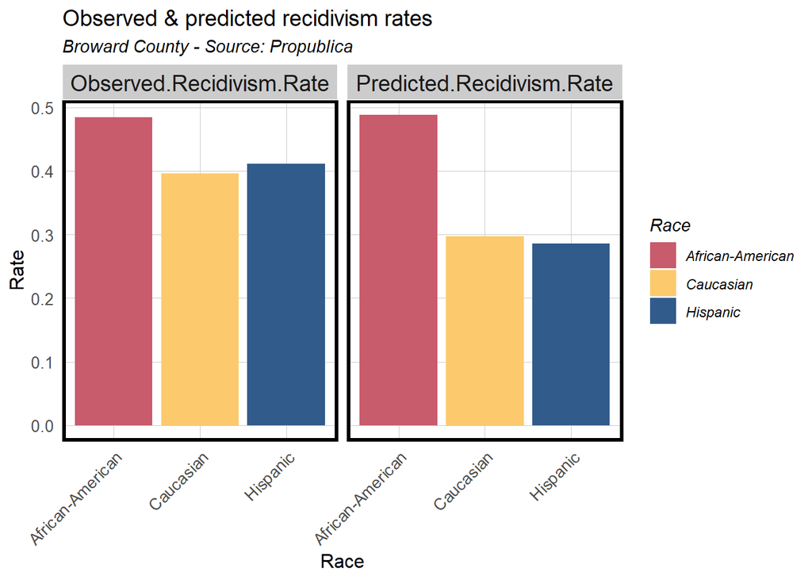

```r
testProbs %>%
  filter(Race == "Caucasian" | Race == "African-American" | Race == "Hispanic") %>%
  filter(regression == "No Race") %>%
  group_by(Race) %>%
  summarize(Observed.Recidivism.Rate = sum(class) / n(),
            Predicted.Recidivism.Rate = sum(predClass) / n())%>%
  select(Race,Observed.Recidivism.Rate,Predicted.Recidivism.Rate)%>%
  gather(key="measure", value="value",c('Observed.Recidivism.Rate','Predicted.Recidivism.Rate'))%>%
    ggplot(.,aes(x=Race, y=value)) +
    geom_bar(aes(fill=Race),position="dodge",stat="identity") +
    facet_wrap(~measure) +
    scale_fill_manual(values = palette_3_colors) +
    labs(title="Observed & predicted recidivism rates ",
         subtitle = "Broward County - Source: Propublica",
         x="Race",y="Rate") +
    theme(axis.text.x = element_text(angle = 45, hjust = 1)) +
    plotTheme()
```

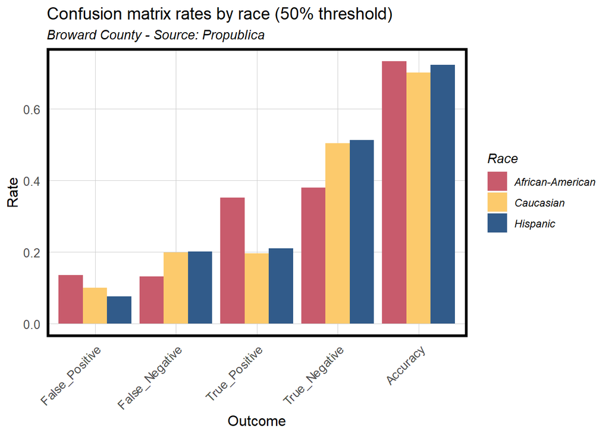

```r
testProbs %>%
  filter(Race == "Caucasian" | Race == "African-American" | Race == "Hispanic") %>%
  filter(regression == "No Race") %>%
  group_by(Race) %>%
  count(predClass,class) %>%
  summarize(sum_trueNeg = sum(n[predClass==0 & class==0]),
            sum_truePos = sum(n[predClass==1 & class==1]),
            sum_falseNeg = sum(n[predClass==0 & class==1]),
            sum_falsePos = sum(n[predClass==1 & class==0]),
            total=sum(n)) %>%
  mutate(True_Positive = sum_truePos / total,
         True_Negative = sum_trueNeg / total,
         False_Negative = sum_falseNeg / total,
         False_Positive = sum_falsePos / total,
         Accuracy = (sum_truePos + sum_trueNeg) / total) %>%
  select(Race, True_Positive, True_Negative, False_Negative, False_Positive,Accuracy) %>%
  gather(key,value,True_Positive:Accuracy) %>%
    ggplot(.,aes(reorder(key, value,FUN = max),value,fill=Race)) +
    geom_bar(aes(fill=Race),position="dodge",stat="identity") +
    scale_fill_manual(values = palette_3_colors) +
    labs(title="Confusion matrix rates by race (50% threshold)",
         subtitle = "Broward County - Source: Propublica",
         x="Outcome",y="Rate") +
    theme(axis.text.x = element_text(angle = 45, hjust = 1)) +
    plotTheme()
```

```r
testProbs %>%
  filter(Race == "Caucasian" | Race == "African-American" | Race == "Hispanic") %>%
  filter(regression == "No Race") %>%
  group_by(Race) %>%
  count(predClass,class) %>%
  summarize(sum_trueNeg = sum(n[predClass==0 & class==0]),
         sum_truePos = sum(n[predClass==1 & class==1]),
         sum_falseNeg = sum(n[predClass==0 & class==1]),
         sum_falsePos = sum(n[predClass==1 & class==0]),
         total=sum(n)) %>%
  mutate(True_Positive = sum_truePos / total,
      True_Negative = sum_trueNeg / total,
      False_Negative = sum_falseNeg / total,
      False_Positive = sum_falsePos / total,
      Accuracy = (sum_truePos + sum_trueNeg) / total) %>%
  select(Race,True_Positive,True_Negative,False_Negative,False_Positive,Accuracy) %>%
  kable() %>%
  kable_styling("striped", full_width = F) %>%
    row_spec(c(1), bold = F, color = "white", background = "#C85B6C") %>%
    row_spec(c(2), bold = F, color = "white", background = "#FCCA6C") %>%
    row_spec(c(3), bold = F, color = "white", background = "#315B8A")
```

| Race | True_Positive | True_Negative | False_Negative | False_Positive | Accuracy |
| --- | --- | --- | --- | --- | --- |
| African-American | 0.3523447 | 0.3802281 | 0.1318124 | 0.1356147 | 0.7325729 |
| Caucasian | 0.1969697 | 0.5037879 | 0.1988636 | 0.1003788 | 0.7007576 |
| Hispanic | 0.2100840 | 0.5126050 | 0.2016807 | 0.0756303 | 0.7226891 |

The trade-off between accuracy and generalizability is that higher accuracy requires higher true negative and true positive rates, the latter favoring race. If you want to make sure that those who have the opportunity to participate in a vocational training program have very low recidivism rates, this algorithm gives more whites and Latins the opportunity than African-Americans. The reason may be that African Americans are being targeted by the police. Therefore, they are again likely to be arrested and sink. The model will always produce biased results unless this potential bias is ruled out. Therefore, this model is not recommended.

## 6. Generating costs and benefits

```r
library(kableExtra)
reci_table <-
   testProbs %>%
      count(predClass, class) %>%
      summarize(True_Negative = sum(n[predClass==0 & class==0]),
                True_Positive = sum(n[predClass==1 & class==1]),
                False_Negative = sum(n[predClass==0 & class==1]),
                False_Positive = sum(n[predClass==1 & class==0])) %>%
       gather(Variable, Count)%>%
  mutate(Revenue =
               ifelse(Variable == "True_Negative", Count * 10600,
               ifelse(Variable == "True_Positive",((10600 - 2000) * (Count * .50)) + (-86040 * (Count * .50)),
               ifelse(Variable == "False_Negative", (-36000) * Count,
               ifelse(Variable == "False_Positive", (10600 - 2000) * Count, 0))))) %>%
    bind_cols(data.frame(Description = c(
              "We predicted no recidivism and there's no recidivism",
              "We predicted recidivism and there is recidivism",
              "We predicted no recidivism but there is recidivism",
              "We predicted recidivism but there's no recidivism")))

kable(reci_table,
       caption = "Cost/Benefit Table") %>%
      kable_styling()
```

Cost/Benefit Table

| Variable | Count | Revenue | Description |
| --- | --- | --- | --- |
| True_Negative | 1365 | 14469000 | We predicted no recidivism and there’s no recidivism |
| True_Positive | 832 | -32215040 | We predicted recidivism and there is recidivism |
| False_Negative | 510 | -18360000 | We predicted no recidivism but there is recidivism |
| False_Positive | 351 | 3018600 | We predicted recidivism but there’s no recidivism |

```r
iterateThresholds <- function(data) {
  x = .01
  all_prediction <- data.frame()
  while (x <= 1) {

  this_prediction <-
      testProbs %>%
      mutate(predOutcome = ifelse(probs > x, 1, 0)) %>%
      count(predOutcome, class) %>%
      summarize(True_Negative = sum(n[predOutcome==0 & class==0]),
                True_Positive = sum(n[predOutcome==1 & class==1]),
                False_Negative = sum(n[predOutcome==0 & class==1]),
                False_Positive = sum(n[predOutcome==1 & class==0]),
            total=sum(n)) %>%
     gather(Variable, Count) %>%
     mutate(Revenue =
               ifelse(Variable == "True_Negative", Count * 10600,
               ifelse(Variable == "True_Positive",((10600 - 2000) * (Count * .50)) + (-18600 * (Count * .50)),
               ifelse(Variable == "False_Negative", (-36000) * Count,
               ifelse(Variable == "False_Positive", (10600 - 2000) * Count, 0)))),
            Threshold = x)

  all_prediction <- rbind(all_prediction, this_prediction)
  x <- x + .01
  }
return(all_prediction)
}
```

```r
whichThreshold <- iterateThresholds(testProbs)
whichThreshold[1:15,]
```

```
## # A tibble: 15 x 4
##    Variable       Count  Revenue Threshold
##    <chr>          <int>    <dbl>     <dbl>
##  1 True_Negative      0        0      0.01
##  2 True_Positive   1342 -6710000      0.01
##  3 False_Negative     0        0      0.01
##  4 False_Positive  1716 14757600      0.01
##  5 total           3058        0      0.01
##  6 True_Negative      0        0      0.02
##  7 True_Positive   1342 -6710000      0.02
##  8 False_Negative     0        0      0.02
##  9 False_Positive  1716 14757600      0.02
## 10 total           3058        0      0.02
## 11 True_Negative      0        0      0.03
## 12 True_Positive   1342 -6710000      0.03
## 13 False_Negative     0        0      0.03
## 14 False_Positive  1716 14757600      0.03
## 15 total           3058        0      0.03
```

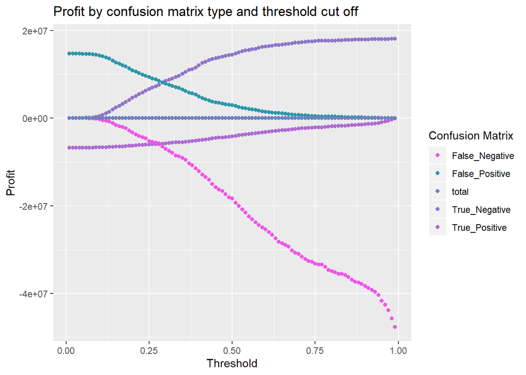

```r
whichThreshold %>%
  ggplot(.,aes(Threshold, Revenue, colour = Variable)) +
  geom_point() +
  scale_colour_manual(values = palette_5_colors[c(5, 1:4)]) +
  labs(title = "Profit by confusion matrix type and threshold cut off",
       y="Profit") +
  guides(colour=guide_legend(title="Confusion Matrix"))
```

```r
whichThreshold_revenue <-
  whichThreshold %>%
    mutate(actualChurn = ifelse(Variable == "True_Positive", (Count * .5),
                         ifelse(Variable == "False_Negative", Count, 0))) %>%
    group_by(Threshold) %>%
    summarize(Revenue = sum(Revenue),
              Actual_Churn_Rate = sum(actualChurn) / sum(Count),
              Actual_Churn_Revenue =  sum(actualChurn * 10600),
              Revenue_Next_Period = Revenue - Actual_Churn_Revenue)

whichThreshold_revenue
```

```
## # A tibble: 99 x 5
##    Threshold Revenue Actual_Churn_Rate Actual_Churn_Revenue Revenue_Next_Period
##        <dbl>   <dbl>             <dbl>                <dbl>               <dbl>
##  1      0.01 8047600             0.110              7112600              935000
##  2      0.02 8047600             0.110              7112600              935000
##  3      0.03 8047600             0.110              7112600              935000
##  4      0.04 8055600             0.110              7112600              943000
##  5      0.05 8059600             0.110              7112600              947000
##  6      0.06 8065600             0.110              7112600              953000
##  7      0.07 8009600             0.110              7123200              886400
##  8      0.08 8015600             0.110              7123200              892400
##  9      0.09 7958600             0.110              7139100              819500
## 10      0.10 7924600             0.110              7149700              774900
## # ... with 89 more rows
```

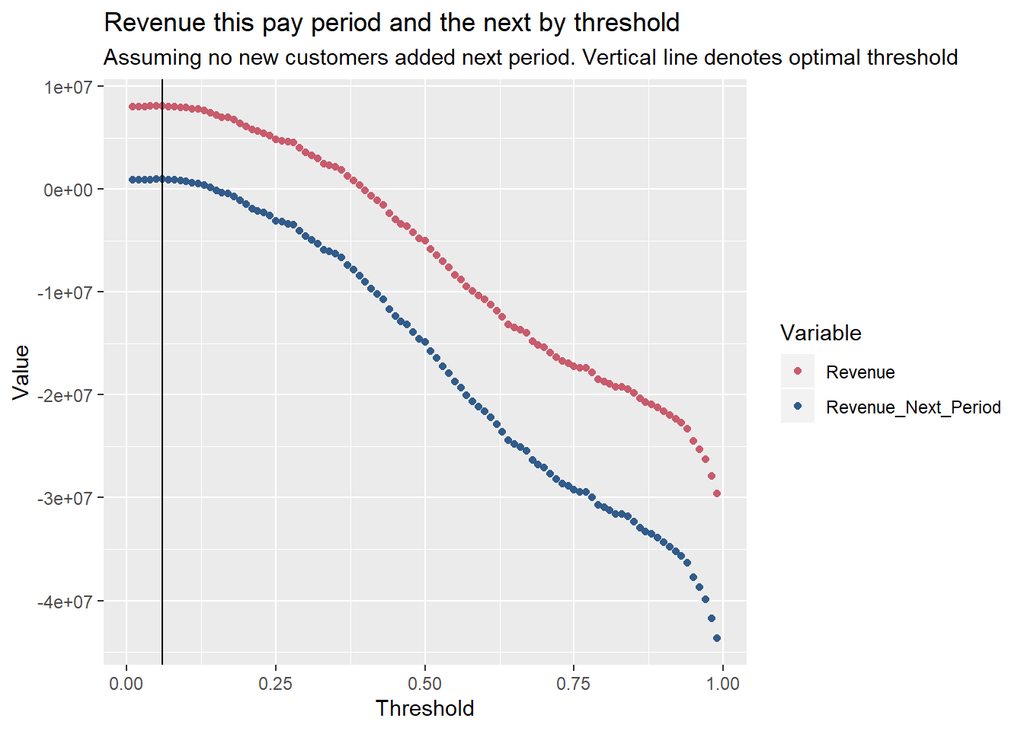

```r
whichThreshold_revenue %>%
  dplyr::select(Threshold, Revenue, Revenue_Next_Period) %>%
  gather(Variable, Value, -Threshold) %>%
  ggplot(aes(Threshold, Value, colour = Variable)) +
    geom_point() +
    geom_vline(xintercept = pull(arrange(whichThreshold_revenue, -Revenue)[1,1])) +
    scale_colour_manual(values = palette_2_colors) +
    labs(title = "Revenue this pay period and the next by threshold",
         subtitle = "Assuming no new customers added next period. Vertical line denotes optimal threshold")
```

If everyone who is predicted to recidivate is enrolled in the program, we can calculate what the societal cost would be by adding up the costs of each of the four possible outcomes and multiplying them by the number of ex-offenders predicted to have that outcome. Since the number of ex-offenders who fall into each outcome varies by the threshold use, we can optimize our model by using the threshold which minimizes the overall cost of all four outcomes.